# Housing Values in Suburbs of Boston

Paras Ahuja

### Motivation and Goals

The data set is standard and is easily obtained from MASS library in R. Our goal is to perform **Exploratory Data Analysis** on this data set and see what insights we can gain.

We are focused on crime rate and how different features impact crime rate.

### Exploratory Data Analysis

We begin by loading the data set into our RStudio environment. Since the data set is in MASS library, simply loading the library will provide us access to this data set.

```r
library(MASS)
data("Boston")
```

Now that the library is loaded, let’s find out the dimension of this data set.

```r
dim(Boston)
```

```
[1] 506  14
```

Our data set contains 506 observations and 14 features. Let’s find out if there are any missing values in the data set.

```r
sum(is.na(Boston))
```

```
[1] 0
```

There are no value marked as NA in our data set. Let’s take a look at how our data set appears.

```r
head(Boston)
```

|  | crim | zn | indus | chas | nox | rm | age | dis | rad | tax | ptratio | black | lstat | medv |
| --- | --- | --- | --- | --- | --- | --- | --- | --- | --- | --- | --- | --- | --- | --- |
| 1 | 0.00632 | 18 | 2.31 | 0 | 0.538 | 6.575 | 65.2 | 4.0900 | 1 | 296 | 15.3 | 396.90 | 4.98 | 24.0 |
| 2 | 0.02731 | 0 | 7.07 | 0 | 0.469 | 6.421 | 78.9 | 4.9671 | 2 | 242 | 17.8 | 396.90 | 9.14 | 21.6 |
| 3 | 0.02729 | 0 | 7.07 | 0 | 0.469 | 7.185 | 61.1 | 4.9671 | 2 | 242 | 17.8 | 392.83 | 4.03 | 34.7 |
| 4 | 0.03237 | 0 | 2.18 | 0 | 0.458 | 6.998 | 45.8 | 6.0622 | 3 | 222 | 18.7 | 394.63 | 2.94 | 33.4 |
| 5 | 0.06905 | 0 | 2.18 | 0 | 0.458 | 7.147 | 54.2 | 6.0622 | 3 | 222 | 18.7 | 396.90 | 5.33 | 36.2 |
| 6 | 0.02985 | 0 | 2.18 | 0 | 0.458 | 6.430 | 58.7 | 6.0622 | 3 | 222 | 18.7 | 394.12 | 5.21 | 28.7 |

```r
summary(Boston)
```

```
      crim                zn             indus            chas
 Min.   : 0.00632   Min.   :  0.00   Min.   : 0.46   Min.   :0.00000
 1st Qu.: 0.08205   1st Qu.:  0.00   1st Qu.: 5.19   1st Qu.:0.00000
 Median : 0.25651   Median :  0.00   Median : 9.69   Median :0.00000
 Mean   : 3.61352   Mean   : 11.36   Mean   :11.14   Mean   :0.06917
 3rd Qu.: 3.67708   3rd Qu.: 12.50   3rd Qu.:18.10   3rd Qu.:0.00000
 Max.   :88.97620   Max.   :100.00   Max.   :27.74   Max.   :1.00000
      nox               rm             age              dis
 Min.   :0.3850   Min.   :3.561   Min.   :  2.90   Min.   : 1.130
 1st Qu.:0.4490   1st Qu.:5.886   1st Qu.: 45.02   1st Qu.: 2.100
 Median :0.5380   Median :6.208   Median : 77.50   Median : 3.207
 Mean   :0.5547   Mean   :6.285   Mean   : 68.57   Mean   : 3.795
 3rd Qu.:0.6240   3rd Qu.:6.623   3rd Qu.: 94.08   3rd Qu.: 5.188
 Max.   :0.8710   Max.   :8.780   Max.   :100.00   Max.   :12.127
      rad              tax           ptratio          black
 Min.   : 1.000   Min.   :187.0   Min.   :12.60   Min.   :  0.32
 1st Qu.: 4.000   1st Qu.:279.0   1st Qu.:17.40   1st Qu.:375.38
 Median : 5.000   Median :330.0   Median :19.05   Median :391.44
 Mean   : 9.549   Mean   :408.2   Mean   :18.46   Mean   :356.67
 3rd Qu.:24.000   3rd Qu.:666.0   3rd Qu.:20.20   3rd Qu.:396.23
 Max.   :24.000   Max.   :711.0   Max.   :22.00   Max.   :396.90
     lstat            medv
 Min.   : 1.73   Min.   : 5.00
 1st Qu.: 6.95   1st Qu.:17.02
 Median :11.36   Median :21.20
 Mean   :12.65   Mean   :22.53
 3rd Qu.:16.95   3rd Qu.:25.00
 Max.   :37.97   Max.   :50.00
```

Let’s see how these features in our data set correlate. However, since we are only focused on crime rate, we will simply look at crime rate and features that have a correlation with it.

**NOTE:** If we were building a predictive model, we would have to focus on multicollinearity and therefore correlation of each feature with other feature will be of importance too but we are only performing EDA with crime rate as the focus.

```r
cor(Boston, method="pearson")[1,]
```

```
       crim          zn       indus        chas         nox          rm
 1.00000000 -0.20046922  0.40658341 -0.05589158  0.42097171 -0.21924670
        age         dis         rad         tax     ptratio       black
 0.35273425 -0.37967009  0.62550515  0.58276431  0.28994558 -0.38506394
      lstat        medv
 0.45562148 -0.38830461
```

We notice that crime rate is highest when there is high accessibility to radial highways. This could be because once a person has committed a crime, they can easily get away from the crime scene. Let’s verify this when rad is greater than the median of 5 and less than 5.

```r
mean(Boston[Boston$rad >= 5, ]$crim)
```

```
[1] 5.664632
```

```r
mean(Boston[Boston$rad < 5, ]$crim)
```

```
[1] 0.2591066
```

Our median rad is 5, which means that we are can expect to see approximately 50% of the data on either side of this value, we notice that lower rad means lower average crime rate and rad rises, crime rate rises along with it. This indicates that accessibility to radial highways definitely has an impact on the crime rate.

Let’s create some plots and graphs to visualize the information we have so far.

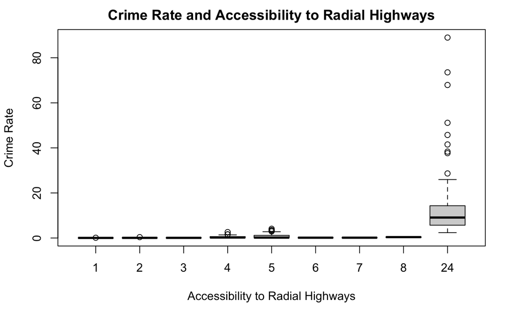

```r
rad <- as.factor(Boston$rad)
plot(x=rad, y=Boston$crim,
     xlab="Accessibility to Radial Highways",
     ylab="Crime Rate",
     main="Crime Rate and Accessibility to Radial Highways")
```

We have an outlier index for rad in our data set. While most of the accessibility index ratings are between 1 - 8, we have a rating of 24 that maybe skewing our results. Let’s dig deeper and see how the data fares if we discount index rating of 24.

```r
boston <- Boston[Boston$rad < 24, ]
mean(boston$crim)
```

```
[1] 0.3856057
```

```r
boston <- Boston[Boston$rad == 24, ]
mean(boston$crim)
```

```
[1] 12.75929
```

Let’s find out how many suburbs actually have a rating of 24.

```r
dim(boston)
```

```
[1] 132  14
```

Our data set contains 506 observations out of which 132 belong to rad rating of 24.

```r
132/506
```

```
[1] 0.2608696
```

Approximately 26.08% of our data is being impacted by this. Let’s see what our correlations look like if we remove rad rating of 24.

```r
boston <- Boston[Boston$rad < 24, ]
cor(boston, method="pearson")[, 1]
```

```
      crim         zn      indus       chas        nox         rm        age
 1.0000000 -0.2887260  0.5006359  0.1355393  0.7465676 -0.2123193  0.4683864
       dis        rad        tax    ptratio      black      lstat       medv
-0.4460934  0.1459919  0.2958862 -0.2378530 -0.5192336  0.3840303 -0.1716970
```

We no longer have such a high correlation with rad anymore. Removing high rad rating is also leading us to see that there is a high correlation between crime rate and nox, which is nitrogen oxides concentration. EPA states the following about NO2:

Breathing air with a high concentration of NO2 can irritate airways in the human respiratory system. Such exposures over short periods can aggravate respiratory diseases, particularly asthma, leading to respiratory symptoms (such as coughing, wheezing or difficulty breathing), hospital admissions and visits to emergency rooms. Longer exposures to elevated concentrations of NO2 may contribute to the development of asthma and potentially increase susceptibility to respiratory infections. People with asthma, as well as children and the elderly are generally at greater risk for the health effects of NO2.

More information on NO2 can be obtained from [here](https://www.epa.gov/no2-pollution/basic-information-about-no2).

We can conclude that discounting for accessibility to radial highways, NO2 is the most important factor.

#### NO2

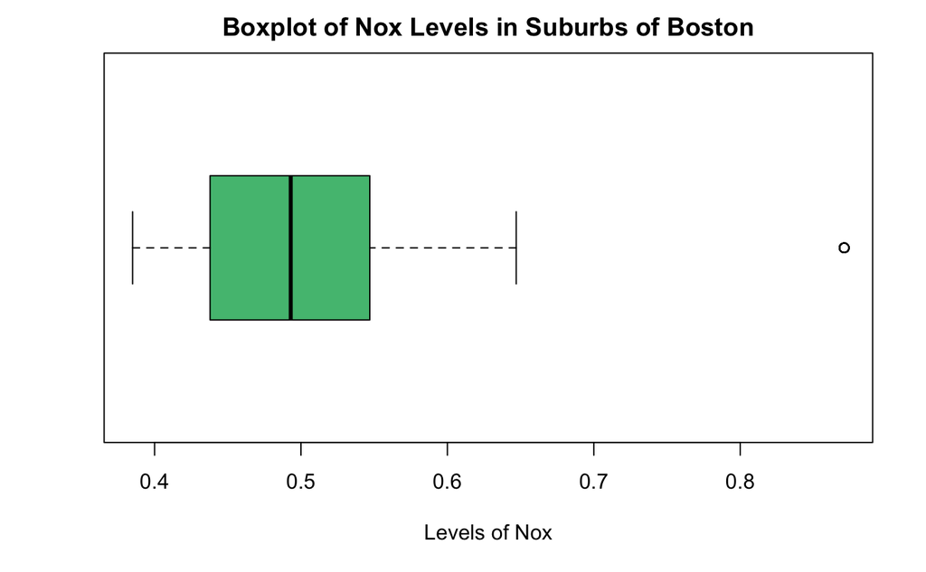

```r
boxplot(boston$nox, horizontal=T, col="#52BE80",
        xlab="Levels of Nox",
        main="Boxplot of Nox Levels in Suburbs of Boston")
```

There seems to be only one outlier in this group. Let’s go ahead and take a look at the range of N02.

```r
range(boston$nox)
```

```
[1] 0.385 0.871
```

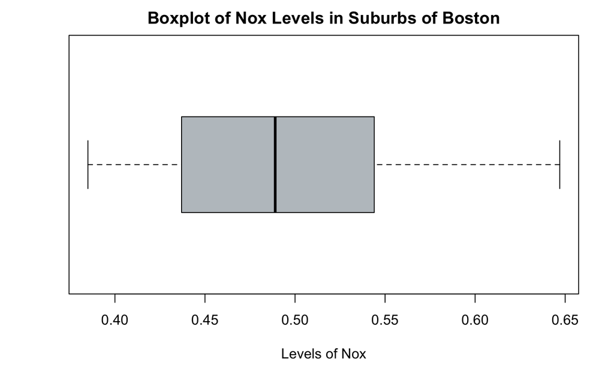

```r
boston <- boston[boston$nox < 0.8, ]
boxplot(boston$nox, horizontal=T, col="#BDC3C7",
        xlab="Levels of Nox",
        main="Boxplot of Nox Levels in Suburbs of Boston")
```

Let’s check if this changes our correlation or not.

```r
cor(boston, method="pearson")[, 1]
```

[output not shown]

So far we have removed two outliers, and these are as follows:

1. rad rating of 24
2. nox of 0.871

At this point we can say that high accessibility rating to radial highways, and high levels of nox in the environment are a significant contributing factor to the crime rates in Boston suburbs.

We are seeing that our correlations have definitely changed however, our top 3 choice still remain top 3.